[figure not shown]

SC(w/o STI)-2

General Description

STARTING/CHARGING SYSTEMS

1. General Description

A: SPECIFICATION

Item Specifications

Vehicle model CVT MT

Starter

Type Reduction type

Model M000T38571 M000T33176

Manufacturer Mitsubishi Electric

Voltage and output 12 V — 1.2 kW 12 V — 1.0 kW

Direction of rotation Counterclockwise (when observed from pinion)

Number of pinion teeth 9 8

No-load characteris-

tics

Voltage 11 V

Current 90 A or less 95 A or less

Rotating

speed

2,370 rpm or more 2,500 rpm or more

Load characteristics

Voltage 7.5 V 7.5 V

Current 300 A 300 A

Torque 10.65 N·m (1.1 kgf-m, 7.8 ft-lb) or more 8.84 N·m (0.9 kgf-m, 6.5 ft-lb) or more

Rotating

speed

840 rpm or more 870 rpm or more

Lock characteristics

Voltage 4 V 4 V

Current 780 A or less 680 A or less

Torque 20 N·m (2.0 kgf-m, 14.8 ft-lb) or more 17 N·m (1.7 kgf-m, 12.5 ft-lb) or more

Generator

Type

Rotating-field three-phase type, voltage regulator built-in type, with load

response control system

Model A2TX5081

Manufacturer Mitsubishi Electric

Voltage and output 12 V — 130 A

Polarity on ground side Negative

Direction of rotation Clockwise (when observed from pulley side)

Stator connection 3-phase type

Output current

1,500 rpm — 50 A or more

2,500 rpm — 111 A or more

5,000 rpm — 133 A or more

Regulated voltage 14.1 — 14.8 V [20°C (68°F)]

Rotor slip ring outer

diameter

Standard 22.7 mm (0.894 in)

Limit 22.1 mm (0.870 in)

Brush length

Standard 22.5 mm (0.886 in)

Limit 5.0 mm (0.197 in)

Battery

Type and capacity 12 V — 48 AH (55D 23L)

CCA 390A

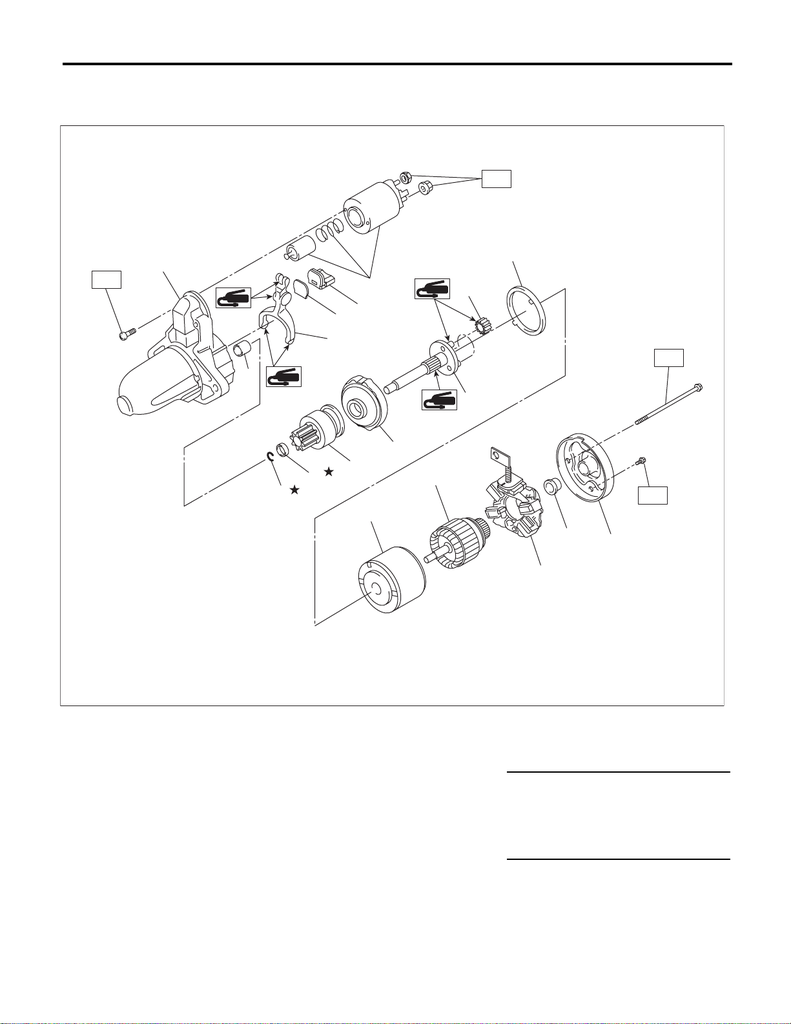

SC(w/o STI)-3

General Description

STARTING/CHARGING SYSTEMS

B: COMPONENT

1. STARTER

(1) Starter housing ASSY (9) Overrunning clutch (17) Sleeve bearing

(2) Sleeve bearing (10) Internal gear ASSY (18) Starter cover ASSY

(3) Shift lever (11) Shaft

(4) Plate (12) Pinion gear Tightening torque: N·m (kgf-m, ft-lb)

(5) Seal rubber (13) Seal rubber T1: 1.4 (0.1, 1.0)

(6) Magnet switch ASSY (14) Yoke ASSY T2: 6 (0.6, 4.4)

(7) Snap ring (15) Armature ASSY T3: 7.5 (0.8, 5.5)

(8) Stopper (16) Brush holder ASSY T4: 10 (1.0, 7.4)

(14)

(1)

(2)

(3)

(4)

(10)

(11)

(12)

(13)

(15)

(5)

(6)

(7)

(8)

(9)

SC-02222

T1

T4

T2

T3

(16)

(17)

(18)

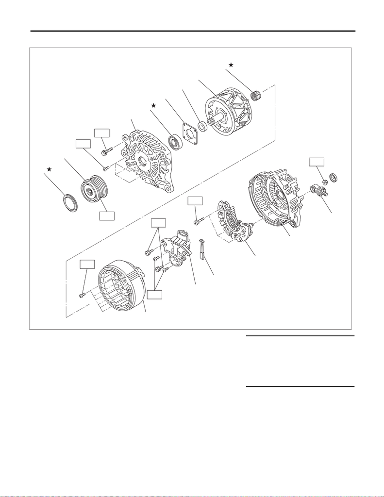

SC(w/o STI)-4

General Description

STARTING/CHARGING SYSTEMS

2. GENERATOR

(1) Cap (8) Bearing Tightening torque: N·m (kgf-m, ft-lb)

(2) Pulley (9) Stator coil T1: 2 (0.2, 1.5)

(3) Front cover (10) IC regulator T2: 3.9 (0.4, 2.9)

(4) Ball bearing (11) Brush T3: 4.4 (0.4, 3.2)

(5) Bearing retainer (12) Rectifier T4: 8.9 (0.9, 6.6)

(6) Spacer (13) Rear cover T5: 108 (11.0, 79.8)

(7) Rotor (14) Terminal B

T4

T1

SC-02884

(4)

(3)

(1)

(2)

(9)

(10)

(11)

(12)

(13)

(14)

(5)

(6)

(7)

(8)

T5

T2

T1

T3

T2

T2

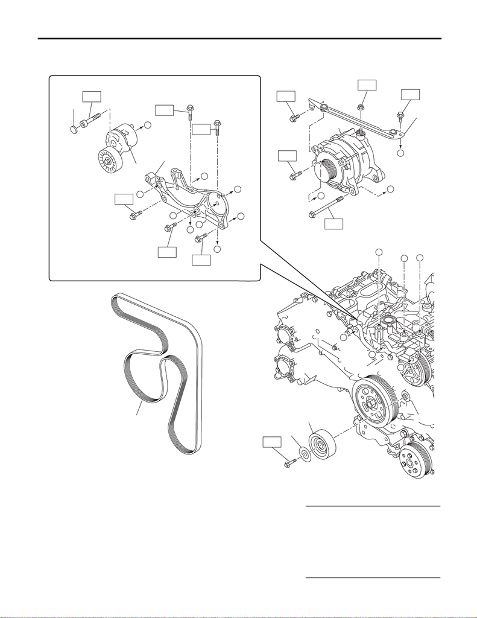

SC(w/o STI)-5

General Description

STARTING/CHARGING SYSTEMS

3. GENERATOR BRACKET

(1) Generator (6) Idler pulley Tightening torque: N·m (kgf-m, ft-lb)

(2) Collector cover bracket (7) Idler pulley cover T1: 6.4 (0.7, 4.7)

(3) Generator bracket (8) V-belt T2: 16 (1.6, 11.8)

(4) V-belt tensioner ASSY T3: 25 (2.5, 18.4)

(5) Cap T4: 36 (3.7, 26.6)

T5: <Ref. to SC(w/o STI)-33,

INSTALLATION, Generator.>

SC-03072

T4

T1

T5

T1

T2

T5

(2)

(1)

(6)

(7)

(8)

F

E

H

G

D

C

B

A

F

T5

T5

T5

T5

T5

(3)

C

T3

(5)

(4)

D

B

A

E

H

G

I

I

[figure not shown]

SC(w/o STI)-6

General Description

STARTING/CHARGING SYSTEMS

4. BATTERY SENSOR

C: CAUTION

• Prior to starting work, pay special attention to the following:

1. Always wear work clothes, a work cap, and protective shoes. Additionally, wear a helmet, protective

goggles, etc. if necessary.

2. Protect the vehicle using a seat cover, fender cover, etc.

3. Prepare the service tools, clean cloth, containers to catch grease and oil, etc.

• Vehicle components are extremely hot immediately after driving. Be wary of receiving burns from heated

parts.

• When performing a repair, identify the cause of trouble and avoid unnecessary removal, disassembly and

replacement.

• Before disconnecting connectors of sensors or units, be sure to disconnect the ground cable from battery.

• Always use the jack-up point when the shop jacks or rigid racks are used to support the vehicle.

• Remove contamination including dirt and corrosion before removal, installation, disassembly or assembly.

• Keep the removed parts in order and protect them from dust and dirt.

• All removed parts, if to be reused, should be reinstalled in the original positions with attention to the correct

directions, etc.

• Bolts, nuts and washers should be replaced with new parts as required.

• Be sure to tighten the fasteners including bolts and nuts to the specified torque.

D: PREPARATION TOOL

1. GENERAL TOOL

(1) Battery sensor Tightening torque: N·m (kgf-m, ft-lb)

T: 7.5 (0.8, 5.5)

TOOL NAME REMARKS

Circuit tester Used for measuring resistance, voltage and current.

SC-03067

(1)

T